# Biophysical Models and Neural Network Architectures for Neural test data

Rose Hedderman EID: rrh2298

4/17/2021

## Project 2

### Introduction.

This report goes over the relationships between spiking data taken from single cortical laayer 5 pyramidal cells after simulation. The dataset contains attributes that contribute to the study of single cortical neurons as deep artificial neural networks. I chose this dataset because I am equally interested in neuroscience and artificial intelligence and this study embodied where they meet. Working with a new dataset also gave me practice looking for and cleaning data that is appropriate for my desired analysis. The dataset hold variables for the evaluation of fitting performance on test data for different neural network structures and three different biophysical models used. These three models are NMDA synpases, AMPA synapses, and AMPA synapses without the SK channel. There were two available tidy datasets and the larger one was used for an increased sample size of 105 rows and 18 columns of data. This was cut down for different analyses below, but the large dataset was a great place to start.

```r
# import needed libraries
library(dplyr)
library(tidyverse)
library(cluster)

# hide warnings due to older version of R
options(warn=-1)

# import dataset
models <- read.csv("C:/Users/roseh/OneDrive/Desktop/Spring 2021/SDS 348/best_results_test_105_models (1).csv", stringsAsFactors=FALSE)

# view the first 6 rows of the dataset 'models'
head(`models`)
```

```
##   biophysical_model_type NN_depth NN_width NN_input_time_window NN_model_type
## 1                   AMPA        1       64                   35           FCN
## 2                   AMPA        1       32                   39           FCN
## 3                   AMPA        1      128                   43           FCN
## 4                   AMPA        1      256                   45           FCN
## 5                   AMPA        1      128                   54           FCN
## 6                   AMPA        1      256                   55           FCN
##   spikes.D.prime spikes.AUC spikes.AUC...1..FP soma.explained.variance..
## 1       3.340230  0.9909092          0.4345988                  95.02454
## 2       3.206526  0.9883158          0.3806042                  94.16525
## 3       3.365291  0.9913348          0.4361554                  95.06362
## 4       3.354546  0.9911545          0.4289646                  95.08548
## 5       3.337530  0.9908623          0.4333841                  95.02461
## 6       3.350060  0.9910783          0.4292489                  95.23931
##   soma.RMSE  soma.MAE spikes.TP...0.1..FP spikes.TP...0.25..FP
```

[output cut: 27 more lines]

### EDA

```r
# graphs - correlation matrix
# view column names to rename columns so correlation matrix dimensions fit
#colnames(models)

models <- models %>%
    # rename variables to fix dimensions of correlation matrix
  rename("depth" = NN_depth, "width" = NN_width, "input_t" = NN_input_time_window,
         "D.prime" = spikes.D.prime, "AUC" = spikes.AUC, "AUC.1" = spikes.AUC...1..FP,
         "sev" = soma.explained.variance.., "s_RMSE" = soma.RMSE, "s_MAE" = soma.MAE,
         "TP.1" = spikes.TP...0.1..FP, "TP.25" = spikes.TP...0.25..FP,
         "AUCstd" = spikes.AUC.std.of.subsets, "sev.stdsub" = soma.explained.variance...std.of.subsets,
         "numTrn" = NN_num_train_samples, "uniTrn" = NN_unique_train_files)


# nummodels if a df of the numeric variables in models
nummodels <- models %>%
  select(-biophysical_model_type, -full.model.filename, -NN_model_type)

nummodels <- nummodels %>%
  scale %>%
  as.data.frame
head(nummodels)
```

```
##       depth      width    input_t     D.prime         AUC      AUC.1       sev
## 1 -1.245682 -0.4664540 -0.8459959  0.06779699  0.28070963 -0.1851356 0.3185441
## 2 -1.245682 -0.8828422 -0.7652968 -0.31789684 -0.01779367 -0.6200840 0.1117246
## 3 -1.245682  0.3663225 -0.6845976  0.14008987  0.32968913 -0.1725963 0.3279498
## 4 -1.245682  2.0318755 -0.6442481  0.10909250  0.30893973 -0.2305212 0.3332110
## 5 -1.245682  0.3663225 -0.4626750  0.06000700  0.27530812 -0.1949202 0.3185611
## 6 -1.245682  2.0318755 -0.4425002  0.09615195  0.30016609 -0.2282309 0.3702380
##       s_RMSE      s_MAE       TP.1      TP.25     AUCstd sev.stdsub     numTrn
## 1 -0.4220773 -0.3952568 -0.4619371 -0.3919605 -0.1887656 -0.3696419  1.3480573
## 2 -0.2122866 -0.1180036 -0.7025039 -0.6941841  0.1551264 -0.2332559 -0.2116784
## 3 -0.4320099 -0.3931435 -0.5768982 -0.3620104 -0.3276153 -0.3304027  2.0066451
## 4 -0.4376183 -0.4310592 -0.7152774 -0.4300788 -0.4120974 -0.2351609  0.1455466
## 5 -0.4220941 -0.4010746 -0.5662537 -0.4028514 -0.3453915 -0.6061135  0.8305955
## 6 -0.4772847 -0.4640152 -0.5981873 -0.3620104 -0.3564175 -0.3348685  0.5424634
##      uniTrn
## 1 0.6885882
## 2 0.5847312
## 3 0.6885882
## 4 0.6539692
## 5 0.6885882
## 6 0.6885882
```

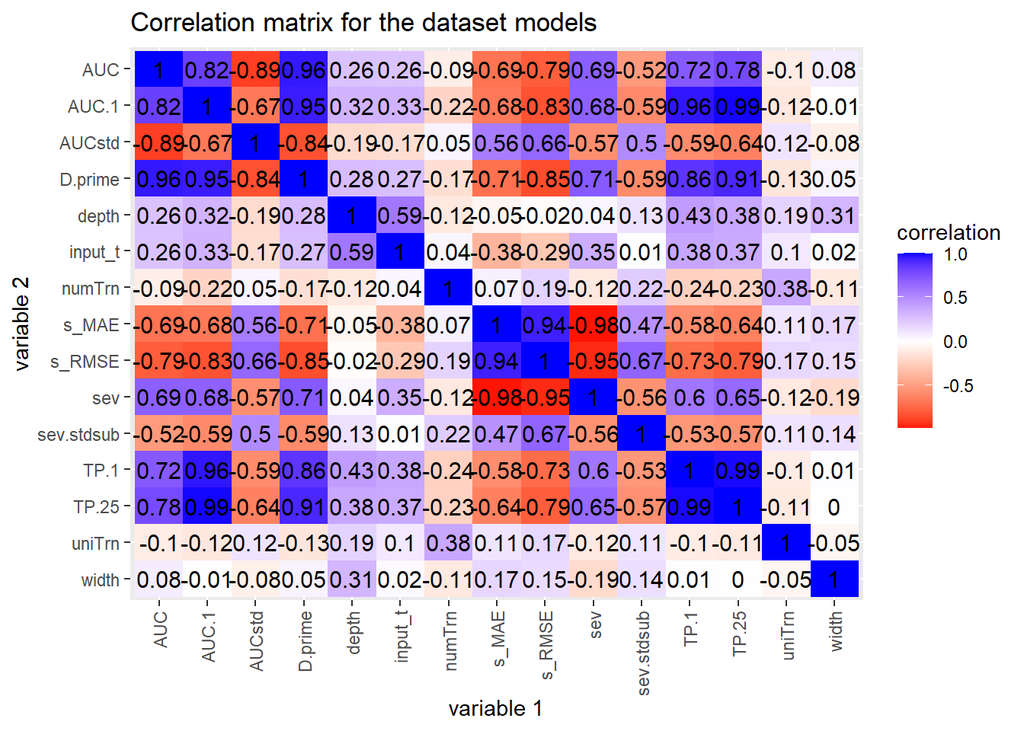

```r
# create a correlation matrix with univariate/bivariate graphs and correlation coefficients
# Find the correlations among the disciplines
cor(nummodels, use = "pairwise.complete.obs") %>%
  # Save as a data frame
  as.data.frame %>%
  # Convert row names to an explicit variable
  rownames_to_column %>%
  # Pivot so that all correlations appear in the same column
  pivot_longer(-1, names_to = "other_var", values_to = "correlation") %>%
  ggplot(aes(rowname, ordered(other_var, levels = rev(sort(unique(other_var)))), fill=correlation)) +
  # Heatmap with geom_tile
  geom_tile() +
  # Change the scale to make the middle appear neutral
  scale_fill_gradient2(low="red",mid="white",high="blue") +
  # Overlay values
  geom_text(aes(label = round(correlation,2)), color = "black", size = 4) +
  # Give title and labels
  labs(title = "Correlation matrix for the dataset models", x = "variable 1", y = "variable 2") +
  theme(axis.text.x = element_text(angle = 90, vjust = 0.5, hjust=1))
```

Notable relationships seen in the correlation matrix that will be tested later on include: AUC.1 ~ D.prime and TP.25 ~ s_RMSE. Some numerical variables showed to have very little correlation so they were not included in the MANOVA analysis in an effort to cut down unnecessary number crunching. These variables include depth, input_t, numTrn, uniTrn, and width.

### MANOVA

Performed a MANOVA test between 10 numerical variables with the most correlation according to the correlation matrix.

```
##                Df  Pillai approx F num Df den Df    Pr(>F)
## NN_model_type   1 0.53987   11.029     10     94 3.262e-12 ***
## Residuals     103
## ---
## Signif. codes:  0 '***' 0.001 '**' 0.01 '*' 0.05 '.' 0.1 ' ' 1
```

```
##  Response AUC :
##                Df    Sum Sq    Mean Sq F value  Pr(>F)
## NN_model_type   1 0.0002825 2.8254e-04  3.8455 0.05258 .
## Residuals     103 0.0075678 7.3474e-05
## ---
## Signif. codes:  0 '***' 0.001 '**' 0.01 '*' 0.05 '.' 0.1 ' ' 1
##
##  Response AUC.1 :
##                Df  Sum Sq  Mean Sq F value    Pr(>F)
## NN_model_type   1 0.17902 0.179021  12.951 0.0004932 ***
## Residuals     103 1.42370 0.013822
## ---
## Signif. codes:  0 '***' 0.001 '**' 0.01 '*' 0.05 '.' 0.1 ' ' 1
##
##  Response AUCstd :
##                Df     Sum Sq    Mean Sq F value Pr(>F)
## NN_model_type   1 1.2710e-07 1.2711e-07  0.8956 0.3462
## Residuals     103 1.4618e-05 1.4192e-07
##
##  Response D.prime :
##                Df  Sum Sq Mean Sq F value  Pr(>F)
## NN_model_type   1  0.7815 0.78150  6.8702 0.01009 *
## Residuals     103 11.7164 0.11375
## ---
## Signif. codes:  0 '***' 0.001 '**' 0.01 '*' 0.05 '.' 0.1 ' ' 1
##
##  Response s_MAE :
##                Df  Sum Sq   Mean Sq F value Pr(>F)
## NN_model_type   1 0.00431 0.0043062   0.172 0.6792
## Residuals     103 2.57857 0.0250346
##
##  Response s_RMSE :
##                Df Sum Sq  Mean Sq F value Pr(>F)
## NN_model_type   1 0.0003 0.000256  0.0046 0.9458
## Residuals     103 5.6773 0.055119
##
##  Response sev :
##                Df  Sum Sq Mean Sq F value Pr(>F)
## NN_model_type   1    1.23  1.2299  0.0706  0.791
## Residuals     103 1794.03 17.4177
##
##  Response sev.stdsub :
##                Df  Sum Sq   Mean Sq F value Pr(>F)
## NN_model_type   1 0.00041 0.0004083  0.0319 0.8586
## Residuals     103 1.31784 0.0127945
##
##  Response TP.1 :
##                Df  Sum Sq  Mean Sq F value    Pr(>F)
## NN_model_type   1 0.09568 0.095682  20.669 1.493e-05 ***
## Residuals     103 0.47682 0.004629
## ---
## Signif. codes:  0 '***' 0.001 '**' 0.01 '*' 0.05 '.' 0.1 ' ' 1
##
##  Response TP.25 :
##                Df  Sum Sq  Mean Sq F value    Pr(>F)
## NN_model_type   1 0.19684 0.196836   16.85 8.115e-05 ***
## Residuals     103 1.20320 0.011682
## ---
## Signif. codes:  0 '***' 0.001 '**' 0.01 '*' 0.05 '.' 0.1 ' ' 1
```

```
##
##  Pairwise comparisons using t tests with pooled SD
##
## data:  models$AUC and models$NN_model_type
##
##     FCN
## TCN 0.053
##
## P value adjustment method: none
```

```
##
##  Pairwise comparisons using t tests with pooled SD
##
## data:  models$AUC.1 and models$NN_model_type
##
##     FCN
## TCN 0.00049
##
## P value adjustment method: none
```

```
##
##  Pairwise comparisons using t tests with pooled SD
##
## data:  models$AUCstd and models$NN_model_type
##
##     FCN
## TCN 0.35
##
## P value adjustment method: none
```

```
##
##  Pairwise comparisons using t tests with pooled SD
##
## data:  models$D.prime and models$NN_model_type
##
##     FCN
## TCN 0.01
##
## P value adjustment method: none
```

```
##
##  Pairwise comparisons using t tests with pooled SD
##
## data:  models$s_MAE and models$NN_model_type
##
##     FCN
## TCN 0.68
##
## P value adjustment method: none
```

```
##
##  Pairwise comparisons using t tests with pooled SD
##
## data:  models$s_RMSE and models$NN_model_type
##
##     FCN
## TCN 0.95
##
## P value adjustment method: none
```

```
##
##  Pairwise comparisons using t tests with pooled SD
##
## data:  models$sev and models$NN_model_type
##
##     FCN
## TCN 0.79
##
## P value adjustment method: none
```

```
##
##  Pairwise comparisons using t tests with pooled SD
##
## data:  models$sev.stdsub and models$NN_model_type
##
##     FCN
## TCN 0.86
##
## P value adjustment method: none
```

```
##
##  Pairwise comparisons using t tests with pooled SD
##
## data:  models$TP.1 and models$NN_model_type
##
##     FCN
## TCN 1.5e-05
##
## P value adjustment method: none
```

```
##
##  Pairwise comparisons using t tests with pooled SD
##
## data:  models$TP.25 and models$NN_model_type
##
##     FCN
## TCN 8.1e-05
##
## P value adjustment method: none
```

#### ANOVA

```
##                Df Sum Sq Mean Sq F value   Pr(>F)
## NN_model_type   1 0.0957 0.09568   20.67 1.49e-05 ***
## Residuals     103 0.4768 0.00463
## ---
## Signif. codes:  0 '***' 0.001 '**' 0.01 '*' 0.05 '.' 0.1 ' ' 1
```

```
##
##  Pairwise comparisons using t tests with pooled SD
##
## data:  models$TP.1 and models$NN_model_type
##
##     FCN
## TCN 1.5e-05
##
## P value adjustment method: none
```

```
##                Df Sum Sq Mean Sq F value   Pr(>F)
## NN_model_type   1 0.1968 0.19684   16.85 8.12e-05 ***
## Residuals     103 1.2032 0.01168
## ---
## Signif. codes:  0 '***' 0.001 '**' 0.01 '*' 0.05 '.' 0.1 ' ' 1
```

```
##
##  Pairwise comparisons using t tests with pooled SD
##
## data:  models$TP.25 and models$NN_model_type
##
##     FCN
## TCN 8.1e-05
##
## P value adjustment method: none
```

```
##                Df Sum Sq Mean Sq F value   Pr(>F)
## NN_model_type   1  0.179 0.17902   12.95 0.000493 ***
## Residuals     103  1.424 0.01382
## ---
## Signif. codes:  0 '***' 0.001 '**' 0.01 '*' 0.05 '.' 0.1 ' ' 1
```

```
##
##  Pairwise comparisons using t tests with pooled SD
##
## data:  models$AUC.1 and models$NN_model_type
##
##     FCN
## TCN 0.00049
##
## P value adjustment method: none
```

The mean difference across groups remains significant after ANOVA tests. All three p-values remain very small, much smaller than 0.05.

#### Type I Error

```r
# probability that you have made at least one type I error
prob <- 1 - (0.95^10)
prob
```

```
## [1] 0.4012631
```

```r
# Bonferonni adjusted = 0.05/ number of tests
bon = 0.05/10
bon
```

```
## [1] 0.005
```

The probability of at least one type I error is 40.12% and the adjusted Bonferroni significance level is 0.005 for 10 variables. The three significant values remain significant after the Bonferroni adjusted comparison value.

#### Assumptions

Assumptions were evaluated visually for the three significant variables.

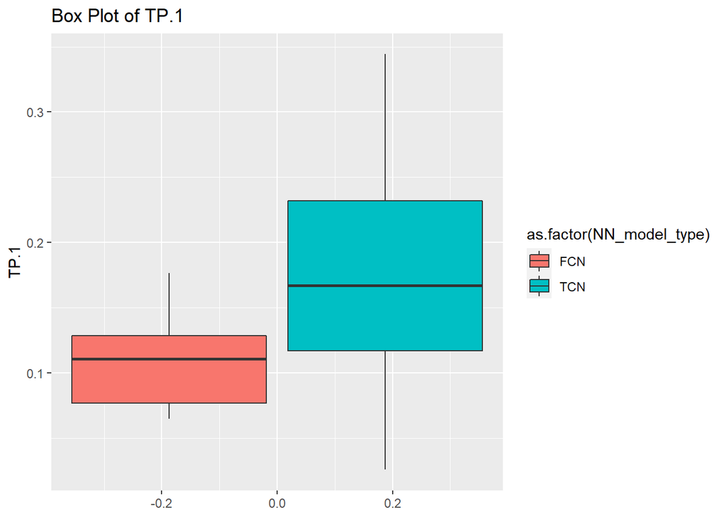

```r
# Check assumptions visually
ggplot(models, aes(y = TP.1)) +
  geom_boxplot(aes(fill = as.factor(NN_model_type))) +
  labs(title = "Box Plot of TP.1")
```

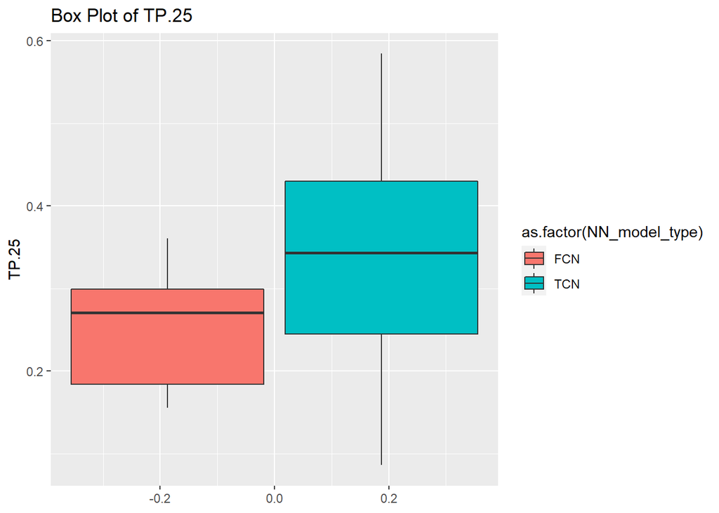

```r
# Check assumptions visually
ggplot(models, aes(y = TP.25)) +
  geom_boxplot(aes(fill = as.factor(NN_model_type)))+
  labs(title = "Box Plot of TP.25")
```

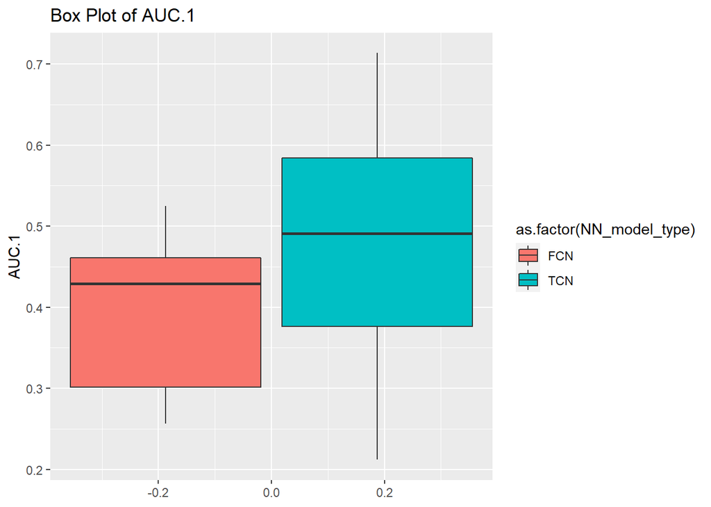

```r
# Check assumptions visually
ggplot(models, aes(y = AUC.1)) +
  geom_boxplot(aes(fill = as.factor(NN_model_type)))+
  labs(title = "Box Plot of AUC.1")
```

All three box plots show a normal distribution for a box plot. There are no outliers for any other the distributions with the center relatively balanced and the NN model type definitely different.

#### Randomization Test

**The null hypothesis is that the observed patten is no different than what we would expect by random chance.**

**The alternative hypothesis is that the observed patten is different than what we would expect by random chance.**

```r
# do randomization test on TP.25
# Observed F-statistic, running anova
obs_F <- 16.85

# find dimensions of dataset to determine MSB and MSW later on
dim(models)
```

```
## [1] 105  18
```

```r
# Randomization test (using replicate)
Fs <- replicate(5000,{
  # Randomly permute the response variable across doses
  new <- models %>%
    mutate(TP.25= sample(TP.25))
  # Compute variation within groups
  SSW <- new %>%
    group_by(NN_model_type) %>%
    summarize(SSW = sum((TP.25 - mean(TP.25))^2)) %>%
    summarize(sum(SSW)) %>%
    pull
  # Compute variation between groups
  SSB <- new %>%
    mutate(mean = mean(TP.25)) %>%
    group_by(NN_model_type) %>%
    mutate(groupmean = mean(TP.25)) %>%
    summarize(SSB = sum((mean - groupmean)^2)) %>%
    summarize(sum(SSB)) %>%
    pull
  # Compute the F-statistic (ratio of MSB and MSW)
  # df for SSB is 3 groups - 1 = 2
  # df for SSW is 105 observations - 2 groups = 103
  (SSB/1)/(SSW/103)
})

# Calculate the proportion of F statistic that are greater than the observed F-statistic
mean(Fs > obs_F)
```

```
## [1] 0
```

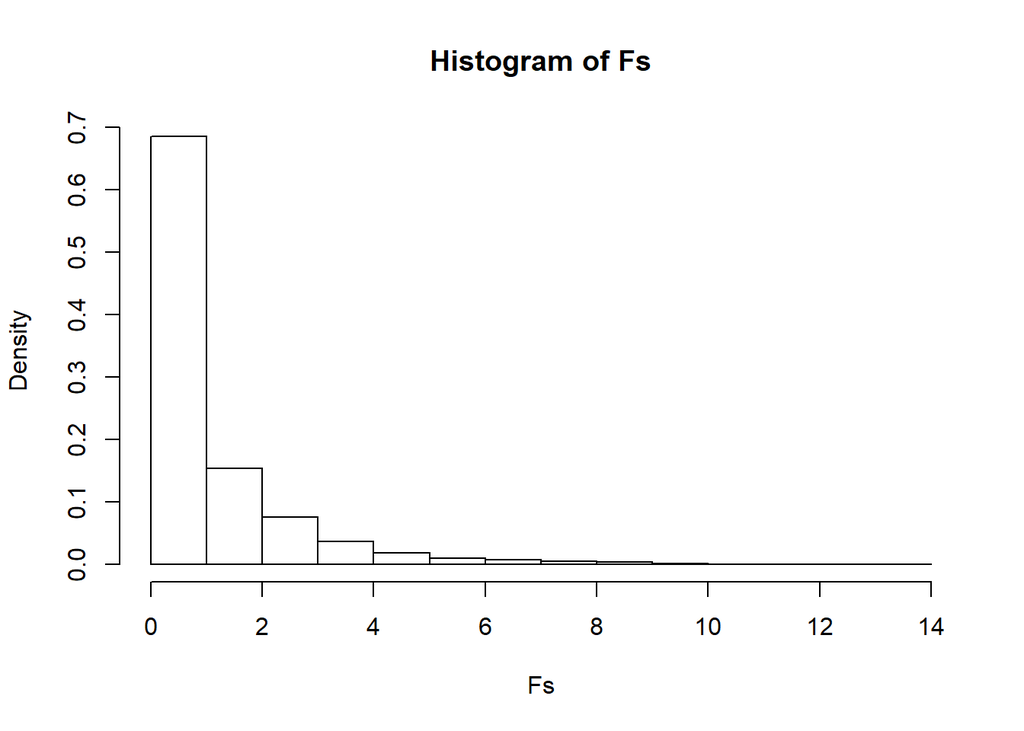

```r
# Represent the distribution of the F-statistics for each randomized sample
hist(Fs, prob=T); abline(v = obs_F, col="red",add=T)
```

The purpose of a randomization is to scramble the data to break any associations present within or between the data. On average, the means will be the same across groups when doing this. The ata was scrambled 5000 times and the F statistic was recorded each time. The histogram of F statistics shows that the randomized F statisitcs are close to zero while the observed F statistic remains much higher around 16.85 as found from the respective anova analysis.

### Linear Regression model

Performed a linear regression between the interaction between the biophysical model type and the centered D.prime value on the AUC.1 value.

```r
# Linear regression
# Center the data around the means (the intercept becomes more informative)
models$D_c <- models$D.prime - mean(models$D.prime)

# Include an interaction term in the regression model with centered predictors
fit_c <- lm(AUC.1 ~ biophysical_model_type * D_c, data = models)
summary(fit_c)
```

```
##
## Call:
## lm(formula = AUC.1 ~ biophysical_model_type * D_c, data = models)
##
## Residuals:
##       Min        1Q    Median        3Q       Max
## -0.064252 -0.014303 -0.002303  0.016282  0.095103
##
## Coefficients:
##                                    Estimate Std. Error t value Pr(>|t|)
## (Intercept)                        0.426559   0.006380  66.858  < 2e-16 ***
## biophysical_model_typeAMPA_SK     -0.008124   0.014133  -0.575    0.567
## biophysical_model_typeNMDA        -0.011359   0.009198  -1.235    0.220
## D_c                                0.492123   0.027146  18.129  < 2e-16 ***
## biophysical_model_typeAMPA_SK:D_c  0.016110   0.044455   0.362    0.718
## biophysical_model_typeNMDA:D_c    -0.276811   0.031461  -8.798 4.54e-14 ***
## ---
## Signif. codes:  0 '***' 0.001 '**' 0.01 '*' 0.05 '.' 0.1 ' ' 1
##
## Residual standard error: 0.02779 on 99 degrees of freedom
## Multiple R-squared:  0.9523, Adjusted R-squared:  0.9499
## F-statistic: 395.2 on 5 and 99 DF,  p-value: < 2.2e-16
```

#### Interpretations

The biophysical model type AMPA_SK is NOT significantly associated with AUC.1 for the biophysical model type, AMPA: for every one unit increase in AMPA_SK, the AUC.1 value goes down by 0.008 (t = -0.575, df = 99, p = 0.567).

The biophysical model type NMDA is NOT significantly associated with AUC.1 for the biophysical model type, AMPA: for every one unit increase in NMDA, the AUC.1 value goes down by 0.011 (t = -1.235, df = 99, p = 0.220).

**D.prime is significantly associated with AUC.1 for the biophysical model type, AMPA: for every one unit increase in D.prime, the AUC.1 value goes up by 0.4921 (t = 18.129, df = 99, p < 0.001).**

There is NOT a significant interaction between the the AMPA_SK biophysical model type and D.prime. The slope for D.prime on AUC.1 is 0.01611 higher for the AMPA_SK biophysical model type compared to the AMPA biophysical model type (t = 0.362, df= 99, p = 0.718).

**There is a significant interaction between the the NMDA biophysical model type and D.prime. The slope for D.prime on AUC.1 is 0.2768 lower for the NMDA biophysical model type compared to the AMPA biophysical model type (t = -8.798, df= 99, p < 0.001).**

#### Graph to visualize the interaction

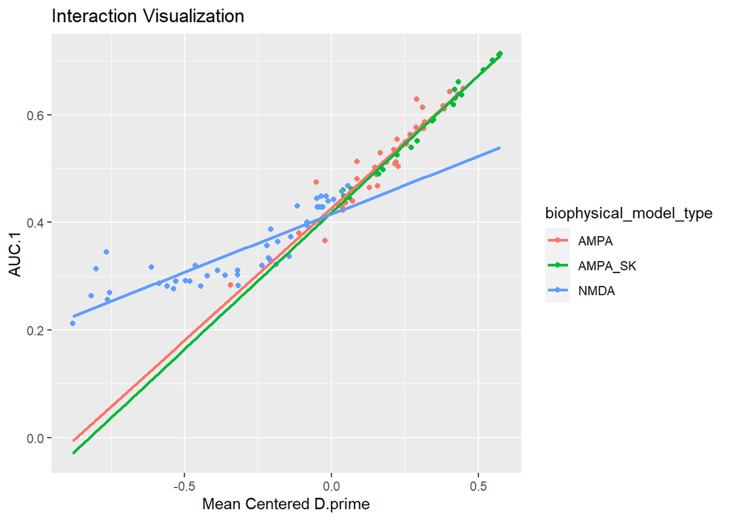

```r
# Create a graph to visualize the interaction between D.prime and AUC.1 on the biophysical model type
ggplot(models, aes(x = D_c, y = AUC.1, color = biophysical_model_type)) +
  geom_point() +
  geom_smooth(method=lm, se=FALSE, fullrange=TRUE) +
  labs(title = "Interaction Visualization", x = "Mean Centered D.prime")
```

#### Variation

```r
# calculate r-squared value using built-in function
summary(fit_c)$r.sq
```

```
## [1] 0.9522938
```

According to the mean-centered distribution, 95.23% of the variation is explained by the model.

#### Check assumptions

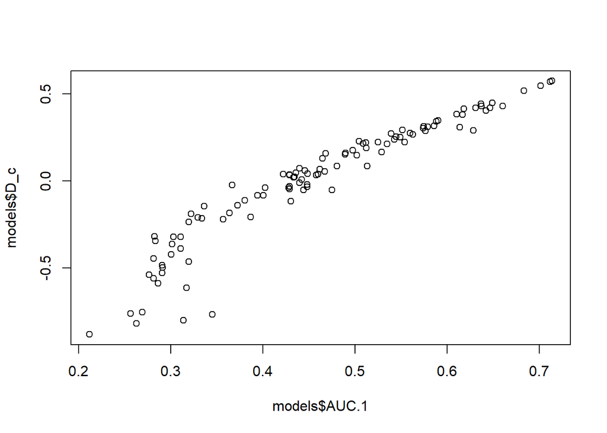

```r
# check assumptions visually
plot(models$AUC.1, models$D_c)
```

```r
fit <- lm(AUC.1 ~ D_c, data = models)
summary(fit)
```

```
##
## Call:
## lm(formula = AUC.1 ~ D_c, data = models)
##
## Residuals:
##       Min        1Q    Median        3Q       Max
## -0.083442 -0.030062 -0.004895  0.021197  0.147100
##
## Coefficients:
##             Estimate Std. Error t value Pr(>|t|)
## (Intercept) 0.457582   0.003981  114.93   <2e-16 ***
## D_c         0.338411   0.011540   29.32   <2e-16 ***
## ---
## Signif. codes:  0 '***' 0.001 '**' 0.01 '*' 0.05 '.' 0.1 ' ' 1
##
## Residual standard error: 0.0408 on 103 degrees of freedom
## Multiple R-squared:  0.893,  Adjusted R-squared:  0.892
## F-statistic: 859.9 on 1 and 103 DF,  p-value: < 2.2e-16
```

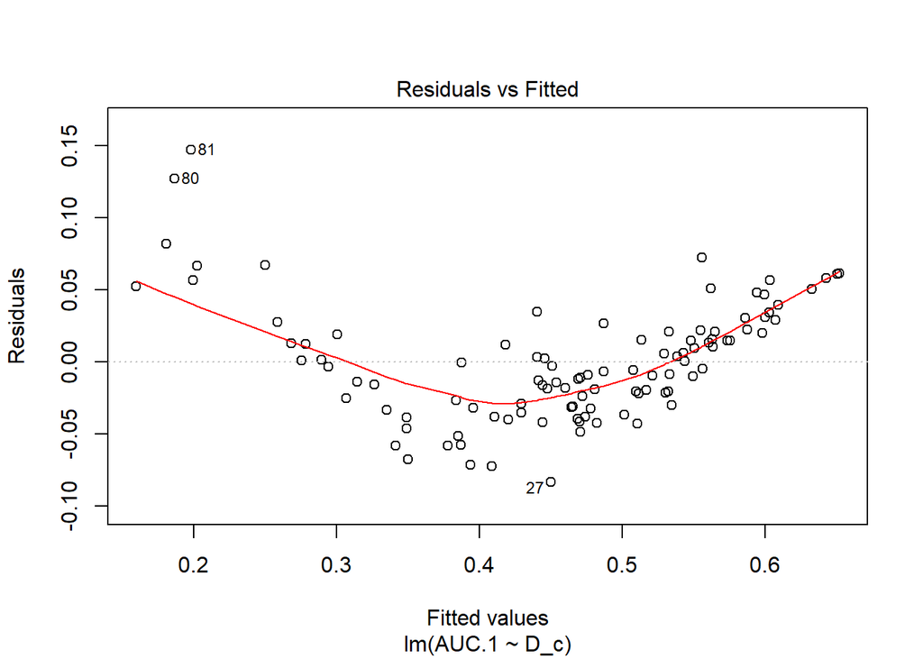

```r
# Residuals vs Fitted values plot
plot(fit, which = 1)
```

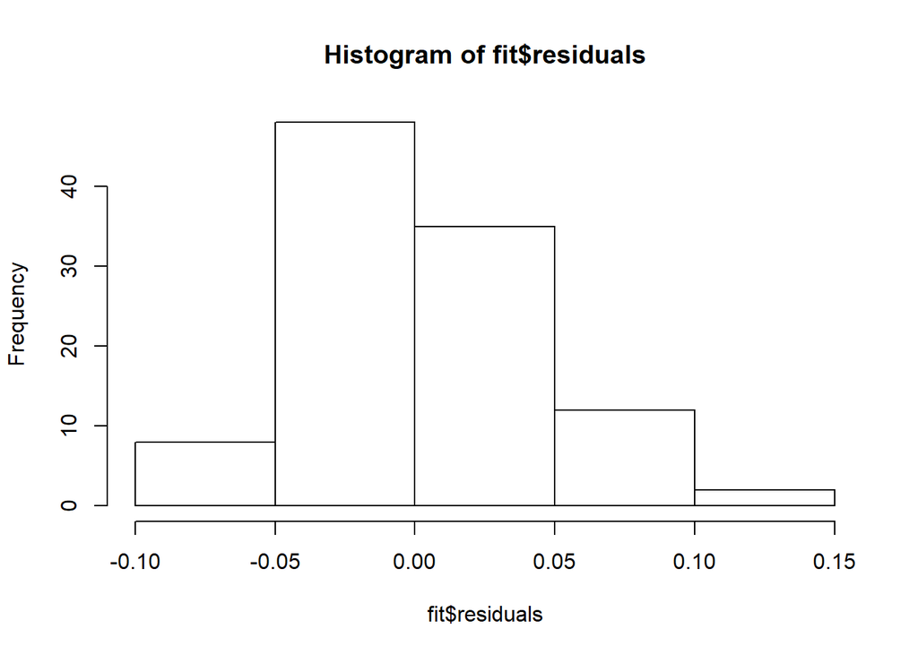

```r
# Histogram of residuals
hist(fit$residuals)
```

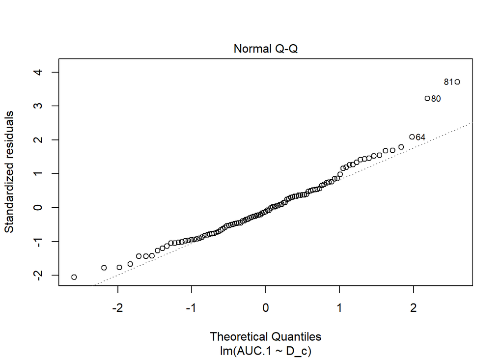

```r
# Q-Q plot for the residuals
plot(fit, which = 2)
```

```r
# check assumptions numerically: normality
# Shapiro-Wilk test
# H0: normality
shapiro.test(fit$residuals)
```

```
##
##  Shapiro-Wilk normality test
##
## data:  fit$residuals
## W = 0.96708, p-value = 0.01031
```

```r
# Kolmogorov-Smirnov test
# H0: normality
ks.test(fit$residuals, "pnorm", mean=0, sd(fit$residuals))
```

```
##
##  One-sample Kolmogorov-Smirnov test
##
## data:  fit$residuals
## D = 0.061811, p-value = 0.8173
## alternative hypothesis: two-sided
```

```r
  # note: the error indicates that there are repeated values for the residuals

# Check assumptions numverically: homoscedasticity
library(sandwich);
# install.packages("lmtest")
library(lmtest)
# Breusch-Pagan test
# H0: homoscedasticity
bptest(fit)
```

```
##
##  studentized Breusch-Pagan test
##
## data:  fit
## BP = 13.869, df = 1, p-value = 0.000196
```

#### Robust Standard Errors

```r
# Robust Standard Errors
# install.packages("sandwich")
library(sandwich)
coeftest(fit, vcov = vcovHC(fit))
```

```
##
## t test of coefficients:
##
##              Estimate Std. Error t value  Pr(>|t|)
## (Intercept) 0.4575816  0.0040735 112.332 < 2.2e-16 ***
## D_c         0.3384114  0.0182066  18.587 < 2.2e-16 ***
## ---
## Signif. codes:  0 '***' 0.001 '**' 0.01 '*' 0.05 '.' 0.1 ' ' 1
```

```r
# original values
# 0.492123   0.027146  18.129  < 2e-16 ***
```

#### Bootstrapped Standard Errors

```r
# When assumptions are violated (homoscedasticity, normality, small sample size)
# use bootstrap samples to estimate coefficients, SEs, fitted values, ...

# Example of estimating coefficients SEs
# Use the function replicate to repeat the process
samp_SEs <- replicate(5000, {
  # Bootstrap your data (resample observations)
  boot_data <- sample_frac(models, replace = TRUE)
  # Fit regression model
  fitboot <- lm(AUC.1 ~ D_c, data = boot_data)
  # Save the coefficients
  coef(fitboot)
})

# Estimated SEs
samp_SEs %>%
  # Transpose the obtained matrices
  t %>%
  # Consider the matrix as a data frame
  as.data.frame %>%
  # Compute the standard error (standard deviation of the sampling distribution)
  summarize_all(sd)
```

```
##   (Intercept)        D_c
## 1 0.004031392 0.01791557
```

```r
# We can also consider a confidence interval for the estimates
samp_SEs %>%
  # Transpose the obtained matrices
  t %>%
  # Consider the matrix as a data frame
  as.data.frame %>%
  # Pivot longer to group by and summarize each coefficient
  pivot_longer(everything(), names_to = "estimates", values_to = "value") %>%
  group_by(estimates) %>%
  summarize(lower = quantile(value,.025), upper = quantile(value,.975))
```

```
## # A tibble: 2 x 3
##   estimates   lower upper
## * <chr>       <dbl> <dbl>
## 1 (Intercept) 0.449 0.465
## 2 D_c         0.307 0.377
```

```r
# Compare to original fit
confint(fit, level = 0.95)
```

```
##                 2.5 %    97.5 %
## (Intercept) 0.4496853 0.4654779
## D_c         0.3155238 0.3612990
```

There were no changes to the p-values using bootstrapped standard errors compared to the original stanard errors and robust standard errors.

### Logistic Regression

Performed a logistic regression after making NN model type a binary variable and analyzing it against TP.25 and s_RMSE.

```r
# binary categorical variable is NN_model_type
# Create a binary variable coded as 0 and 1
models <- models %>%
  mutate(y = ifelse(NN_model_type == "FCN", 1, 0))

# Consider a logistic model with the two numeric variables, TP.25  and s_RMSE
log_model <- glm(y ~ TP.25 + s_RMSE, data = models, family = "binomial")
summary(log_model)
```

```
##
## Call:
## glm(formula = y ~ TP.25 + s_RMSE, family = "binomial", data = models)
##
## Deviance Residuals:
##     Min       1Q   Median       3Q      Max
## -3.3496  -0.3601  -0.0899   0.2794   1.6325
##
## Coefficients:
##             Estimate Std. Error z value Pr(>|z|)
## (Intercept)   33.716      7.340   4.593 4.36e-06 ***
## TP.25        -59.115     12.657  -4.670 3.01e-06 ***
## s_RMSE       -25.371      5.596  -4.534 5.79e-06 ***
## ---
## Signif. codes:  0 '***' 0.001 '**' 0.01 '*' 0.05 '.' 0.1 ' ' 1
##
## (Dispersion parameter for binomial family taken to be 1)
##
##     Null deviance: 127.423  on 104  degrees of freedom
## Residual deviance:  57.207  on 102  degrees of freedom
## AIC: 63.207
##
## Number of Fisher Scoring iterations: 7
```

#### Interpretations of coeffecient estimates in context

Interpretations for coefficient of TP.25 holding s_RMSE constant: a one unit increase in TP.25 decreases the log-odds of the NN model type being FCN by 59.115.

Interpretations for coefficient of s_RMSE holding TP.25 constant: a one unit increase in s_RMSE decreases the log-odds of the NN model type being FCN by 25.371.

#### Confusion Matrix

```r
# Add predicted probabilities to the dataset
models$prob <- predict(log_model, type = "response")

# Predicted outcome is based on the probability of malignant
# if the probability is greater than 0.5, the NN model type is FCN
models$predicted <- ifelse(models$prob > .5, "FCN", "TCN")
# Confusion matrix
table(truth = models$NN_model_type, prediction = models$predicted)
```

```
##      prediction
## truth FCN TCN
##   FCN  23   8
##   TCN   4  70
```

```r
# Accuracy (correctly classified cases)
(23 + 70)/105
```

```
## [1] 0.8857143
```

```r
# Sensitivity (True Positive Rate, TPR)
70/74
```

```
## [1] 0.9459459
```

```r
# Specificity (True Negative Rate, TNR)
23/31
```

```
## [1] 0.7419355
```

```r
# Precision (Positive Predictive Value, PPV)
70/78
```

```
## [1] 0.8974359
```

#### Plot density of log-odds

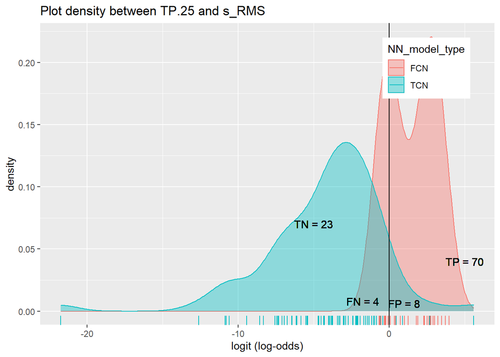

```r
# binary categorical variable is NN_model_type

# Predicted log odds
models$logit <- predict(log_model, type = "link")

# Density plot of log-odds for each outcome
models %>%
  ggplot() +
  geom_density(aes(logit, color = NN_model_type, fill = NN_model_type), alpha = .4) +
    geom_rug(aes(logit, color = NN_model_type)) +
  geom_text(x = -5, y = .07, label = "TN = 23") +
  geom_text(x = -1.75, y = .008, label = "FN = 4") +
  geom_text(x = 1, y = .006, label = "FP = 8") +
  geom_text(x = 5, y = .04, label = "TP = 70") +
  theme(legend.position = c(.85,.85)) +
  geom_vline(xintercept = 0) +
  xlab("logit (log-odds)") +
  labs(title = "Plot density between TP.25 and s_RMS")
```

#### ROC plot and AUC

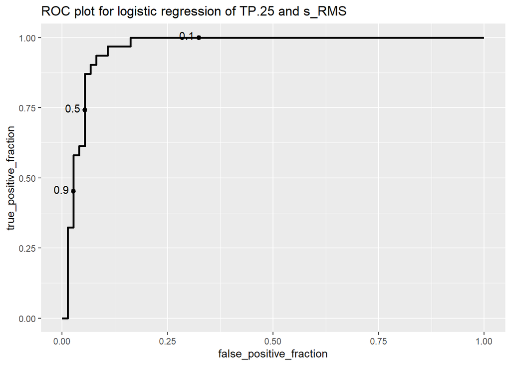

```r
# Call the library plotROC
library(plotROC)

# Plot ROC depending on values of y and its probabilities displaying some cutoff values
ROCplot1 <- ggplot(models) +
  geom_roc(aes(d = y, m = prob), cutoffs.at = list(0.1, 0.5, 0.9)) +
  labs(title = "ROC plot for logistic regression of TP.25 and s_RMS")
ROCplot1
```

```r
# Calculate the area under the curve still using the library plotROC with function calc_auc
calc_auc(ROCplot1)
```

```
##   PANEL group       AUC
## 1     1    -1 0.9598954
```

The ROC plot shows a line very close to the top left corner and fr from the diagonal. This suggests that there a a high true positive rate and low false positive rate. These conclusions help determine that the model is good. The AUC value is 0.9598. The AUC is the area under the curve and suggests predictive accuracy. This high value means that the model is good.